[figure not shown]

# Artificial Intelligence and Machine Learning

## Applied Statistics - Project

## E-news Express : Landing page redesign effectiveness

[figure not shown]

# **Problem Statement**

## Business Context

The advent of e-news, or electronic news, portals has offered us a great opportunity to quickly get updates on the day-to-day events occurring globally. The information on these portals is retrieved electronically from online databases, processed using a variety of software, and then transmitted to the users. There are multiple advantages of transmitting news electronically, like faster access to the content and the ability to utilize different technologies such as audio, graphics, video, and other interactive elements that are either not being used or aren’t common yet in traditional newspapers.

E-news Express, an online news portal, aims to expand its business by acquiring new subscribers. With every visitor to the website taking certain actions based on their interest, the company plans to analyze these actions to understand user interests and determine how to drive better engagement. The executives at E-news Express believe that there has been a decline in new monthly subscribers compared to the past year because the current webpage is not designed well enough in terms of the outline & recommended content to keep customers engaged long enough to decide to subscribe.

[Companies often analyze user responses to two variants of a product to decide which of the two variants is more effective. This experimental technique, known as A/B testing, is used to determine whether a new feature attracts users based on a chosen metric.]

## Objective

The design team of the company has researched and created a new landing page that has a new outline & more relevant content compared to the old page. To test the effectiveness of the new landing page in gathering new subscribers, the Data Science team experimented by randomly selecting 100 users and dividing them equally into two groups. The existing landing page was served to the first group (control group) and the new landing page to the second group (treatment group). Data regarding the interaction of users in both groups with the two versions of the landing page was collected. Being a data scientist in E-news Express, you have been asked to explore the data and perform a statistical analysis (at a significance level of 5%) to determine the effectiveness of the new landing page in gathering new subscribers for the news portal by answering the following questions:

1. Do the users spend more time on the new landing page than on the existing landing page?
2. Is the conversion rate (the proportion of users who visit the landing page and get converted) for the new page greater than the conversion rate for the old page?
3. Does the converted status depend on the preferred language?
4. Is the time spent on the new page the same for the different language users?

## Data Dictionary

The data contains information regarding the interaction of users in both groups with the two versions of the landing page.

1. `user_id` - Unique user ID of the person visiting the website
2. `group` - Whether the user belongs to the first group (control) or the second group (treatment)
3. `landing_page` - Whether the landing page is new or old
4. `time_spent_on_the_page` - Time (in minutes) spent by the user on the landing page
5. `converted` - Whether the user gets converted to a subscriber of the news portal or not
6. `language_preferred` - language chosen by the user to view the landing page

# **Installing and Importing the necessary libraries**

## Local Installation

**Please Note:**

- The notebook is run using a local jupyter running on a uv environment
- No packages are installed via the notebook. They are used from the uv env
- Local env is a Macbook M3 (Google colab not used). Used to manage session timeout challenge of google colab

```python
import sys
sys.executable
```

```
'/Users/sriram/GL/2025-PGP/09-Applied-Stats/.venv/bin/python3.13'
```

```python
!uv pip list
```

[output not shown]

[output cut: 66 more lines]

[output not shown]

## Importing libraries

Following important libraries are loaded

1. Pandas & Numpy
2. Matplotlib, Seaborn
3. Scipy
4. Statsmodels

```python
# Libraries to help with reading, manipulating data and working with arrays
import pandas as pd
import numpy as np

# Libraries to help with data visualization
import matplotlib.pyplot as plt
import seaborn as sns

# Library for statistical tests, Scientific and numerical computing
import scipy as scipy

# import specific statistical tests from scipy.stats
from scipy.stats import ttest_ind
from scipy.stats import chi2_contingency
from scipy.stats import shapiro
from scipy.stats import levene
from scipy.stats import f_oneway
from scipy.stats import f

# import specific distributions from scipy.stats
from scipy.stats import t
from scipy.stats import norm
from scipy.stats import chi2

# Library for statistical models
from statsmodels.stats.proportion import proportions_ztest

%matplotlib inline

# Removes the limit for the number of displayed columns
pd.set_option("display.max_columns", None)

# Removes the limit for the number of displayed characters in a column
pd.set_option('display.max_colwidth', None)

# Sets the limit for the number of displayed rows
pd.set_option("display.max_rows", 100)

# import and filter warnings
import warnings
warnings.filterwarnings("ignore")

# check versions of scipy
print(f"scipy version: {scipy.__version__}")
```

```
scipy version: 1.16.3
```

# Problem Definition & Exploratory Data Analysis (EDA)

## Problem Definition

As a data scientist in E-news Express, following is expected.

- Explore the data and perform a statistical analysis (at a significance level of 5%) to determine the effectiveness of the new landing page in gathering new subscribers for the news portal.
- To achieve the above, answer the following questions:
1. Do the users spend more time on the new landing page than on the existing landing page?
2. Is the conversion rate (the proportion of users who visit the landing page and get converted) for the new page greater than the conversion rate for the old page?
3. Does the converted status depend on the preferred language?
4. Is the time spent on the new page the same for the different language users?

## Loading the dataset

```python
# Load the dataset from a CSV file into a Pandas DataFrame
enews_express_data = df = pd.read_csv("abtest.csv")
```

```python
# Create a copy of the dataframe
df = enews_express_data.copy()
```

## Data Overview

### Shape of the data

```python
# print the dataset shape
df.shape
```

```
(100, 6)
```

- The dataset contains 100 rows and 6 columns.

### Data types of various attributes

```python
# Display the column names of the dataset
df.columns
```

```
Index(['user_id', 'group', 'landing_page', 'time_spent_on_the_page',
       'converted', 'language_preferred'],
      dtype='object')
```

- The 6 columns are matching as per the data dictionary provided in the problem statement

### Data types

```python
# checking column datatypes and number of non-null values
df.info()
```

```
<class 'pandas.core.frame.DataFrame'>
RangeIndex: 100 entries, 0 to 99
Data columns (total 6 columns):
 #   Column                  Non-Null Count  Dtype
---  ------                  --------------  -----
 0   user_id                 100 non-null    int64
 1   group                   100 non-null    object
 2   landing_page            100 non-null    object
 3   time_spent_on_the_page  100 non-null    float64
 4   converted               100 non-null    object
 5   language_preferred      100 non-null    object
dtypes: float64(1), int64(1), object(4)
memory usage: 4.8+ KB
```

- There are 4 object type columns and 2 numerical type columns

### First '5' rows and identifier Column

```python
# Display the first five rows of the dataset
df.head()
```

|  | user_id | group | landing_page | time_spent_on_the_page | converted | language_preferred |
| --- | --- | --- | --- | --- | --- | --- |
| 0 | 546592 | control | old | 3.48 | no | Spanish |
| 1 | 546468 | treatment | new | 7.13 | yes | English |
| 2 | 546462 | treatment | new | 4.40 | no | Spanish |
| 3 | 546567 | control | old | 3.02 | no | French |
| 4 | 546459 | treatment | new | 4.75 | yes | Spanish |

```python
# Print the unique count in the identifier column `user_id`
df['user_id'].nunique()
```

```
100
```

- There are 100 unique users in the dataset as per the `user_id` column

### Observation of data types

- Identifier Column
  1. `user_id`
- Numerical Columns
  1. `time_spent_on_the_page`
- Categorical Columns
  1. `group`
  2. `landing_page`
  3. `converted`
  4. `language_preferred`

### Missing Values

```python
# checking for missing values
df.isnull().sum()
```

```
user_id                   0
group                     0
landing_page              0
time_spent_on_the_page    0
converted                 0
language_preferred        0
dtype: int64
```

- The dataset does not have any missing values in any column.

### Duplicate values

```python
# checking for duplicate values
df.duplicated().sum()
```

```
np.int64(0)
```

- There are no duplicate values in the dataset

### Category columns validation

```python
# define the list of categorical column names in a single variable
category_columns =['group', 'landing_page', 'converted', 'language_preferred']

# Print feature value counts in percentage
for feature in category_columns:
    counts = df[feature].value_counts()
    print(f"{feature}: ", end='')
    print(' | '.join([f"{idx}: {val}" for idx, val in counts.items()]))
```

```
group: control: 50 | treatment: 50
landing_page: old: 50 | new: 50
converted: yes: 54 | no: 46
language_preferred: Spanish: 34 | French: 34 | English: 32
```

- `group` column has two unique values - control and treatment
  - Data is evenly distributed with 50 users in each group
- `landing_page` column has two unique values - old and new
  - **Note :** We can check whether the `group` and `landing_page` columns are aligned as per the experiment design in the next section
- `converted` column has two unique values - yes and no
  - There are 54 (yes) users converted and 46 users not converted (no)
  - We can infer that the overall conversion rate is 54% and the data distribution is slightly skewed towards converted users
- `language_preferred` column has three unique values - English, Spanish and French
  - English language has 32 users, Spanish and French have 34 users each
  - We can infer that the language preference is uniformly distributed among the users

#### Alignment check between `group` and `landing_page` columns

```python
# Using a crosstab check if the `group` and `landing_page` columns are aligned as mentioned in the problem statement
alignment_check = pd.crosstab(df['group'], df['landing_page'])
alignment_check
```

| landing_page group | new | old |
| --- | --- | --- |
| control | 0 | 50 |
| treatment | 50 | 0 |

```python
# Assert to ensure alignment is as per experiment design
assert alignment_check.loc['control', 'old'] == 50 and alignment_check.loc['treatment', 'new'] == 50, "Alignment between group and landing_page is incorrect"
```

- The `group` and `landing_page` columns are aligned as per the experiment design from the crosstab above
- The assert statement also confirms the same

### Numerical column validation

- Numerical column in the dataset is `time_spent_on_the_page` will be checked for negative values

```python
# List of numerical features in the dataset (excluding 'user_id' as it is an identifier)
numeric_features = ['time_spent_on_the_page']

# Create a dictionary to store columns with negative values
negative_values = {}

# Loop through each numerical column to check for negatives
for col in numeric_features:
    # Filter rows where the column has negative values
    negatives = df[df[col] < 0][col]

    # If any negative values exist, store them in the dictionary
    if not negatives.empty:
        negative_values[col] = negatives

# Display the columns with negative values (if any)
negative_values
```

```
{}
```

- There are no negative values in the numerical column `time_spent_on_the_page`

## Descriptive Statistics

- Descriptive statistics will be generated for the numerical column `time_spent_on_the_page`
- This will provide insights into the central tendency, dispersion, and overall distribution of time spent on the landing pages
- The statistics will help in understanding user engagement and inform the subsequent hypothesis tests

```python
# descriptive statistics for the numerical column 'time_spent_on_the_page'
df['time_spent_on_the_page'].describe().T
```

```
count    100.000000
mean       5.377800
std        2.378166
min        0.190000
25%        3.880000
50%        5.415000
75%        7.022500
max       10.710000
Name: time_spent_on_the_page, dtype: float64
```

**Observations:**

- Mean 5.38 and median 5.415 are close indicating roughly symmetric central mass.
- Standard deviation is 2.38, coefficient of variation is 0.44 (moderate relative spread).
- Time Range is wide (0.19 to 10.71) with very low and high extremes.
- IQR is 3.88–7.02 (width ~3.14).
- Likely mild right tail

**Analysis:**

- The near equality of mean and median with moderate spread indicates a roughly symmetric, stable central tendency suitable for parametric tests
- Mild right skew and wide range show heterogeneous engagement with a small subset of high dwell times that may drive conversion, while the absence of strong skew suggests no immediate data transformation is required (apart from checking extreme high values)

## Univariate Analysis

### Numerical variables and histogram

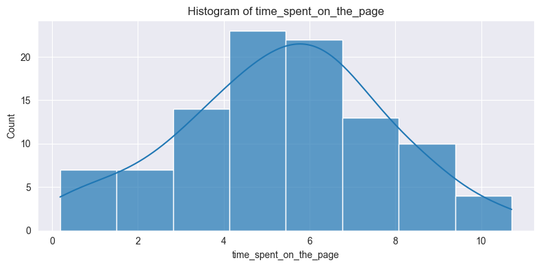

```python
# define the plot figure size
plt.figure(figsize=(8,4))

# plotting the histogram for each numerical feature
for i, feature in enumerate(numeric_features):
    plt.subplot(1, 1, i+1)    # assign a subplot in the main plot
    plt.title(f"Histogram of {feature}")
    sns.histplot(data=df, x=feature, kde=True, alpha=0.7)    # plot the histogram on log scale

plt.tight_layout();   # to add spacing between plots
plt.show()
```

[output not shown]

- `time_spent_on_the_page` is continuous and positive
- The range is roughly between 0 (min) and 11 (max) with a moderate spread
- Distribution appears unimodal, with peak around 5 and 6 i.e., Most users spend mid‑range time
- The distribution is slightly right tailed with a mild positive skew as there are few higher time values
- The mean/median is likely to be closer to 5 or 6. The Stats summary will be used later to check this
- There are no obvious extreme outliers. But the high values in 10 to 11 will be checked later

### Numerical variables and Box plots

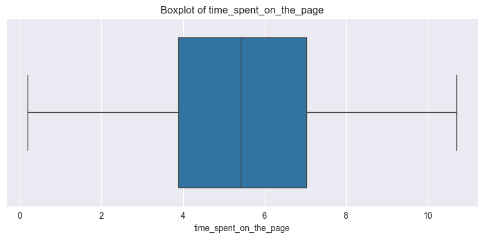

```python
# define the plot figure size
plt.figure(figsize=(8,4))

# plotting the boxplots for each numerical feature
for i, feature in enumerate(numeric_features):
    plt.subplot(1, 1, i+1)    # assign a subplot in the main plot
    plt.title(f"Boxplot of {feature}")
    sns.boxplot(data=df, x=feature)    # plot the boxplot

plt.tight_layout();   # to add spacing between plots
plt.show()
```

**Analysis:**

- Time spent by user is spanning roughly 0 to 11
  - Middle 50% (IQR) about 4 to 7 minutes, median is near 5–6.
- Boxplot too confirms Unimodal distribution with mild right tail
  - mean likely close to median
  - Only a slight positive skew
- No visible extreme outliers as there are no points beyond whiskers
  - high values near 10–11 appear plausible.
- Moderate variability (IQR ~ 3 minutes) relative to median, giving adequate dispersion for subsequent hypothesis tests

### Category variables and Count plots

- count plots will be drawn and analysed for categorical features

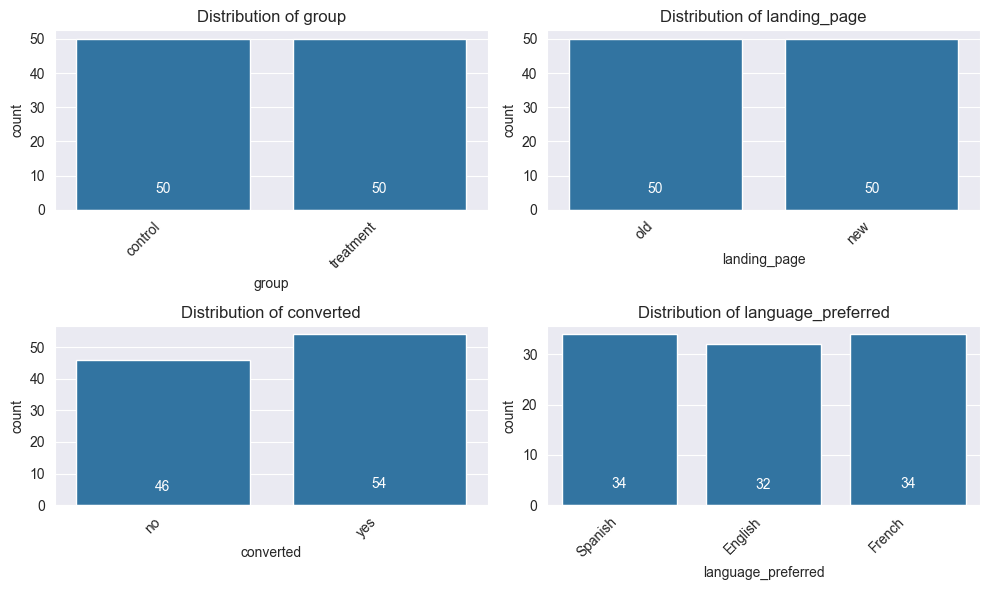

```python
# Plot figure size of 12x12
plt.figure(figsize=(10,6))
total = len(df)

# iterate category features and plot count plot
for i, feature in enumerate(category_columns):
    # Plot setup: 3 rows × 2 columns = 6 subplots
    ax = plt.subplot(2,2, i + 1)
    sns.countplot(data=df, x=feature, ax=ax)

    # Add count labels to each bar
    for p in ax.patches:
        height = p.get_height()
        if height == 0:
            continue
        count = f'{int(height)}'
        label_x = p.get_x() + p.get_width() / 2.

        if height < 0.05 * total:  # Short bars = show label above the bar
            ax.text(
                label_x,
                height + (0.01 * total),
                count,
                color='black',
                fontsize=10,
                ha='center'
            )
        else:  # Tall bars = show label inside with white text
            ax.text(
                label_x,
                height * 0.1,
                count,
                color='white',
                fontsize=10,
                ha='center'
            )

    ax.set_title(f'Distribution of {feature}')
    ax.set_xticklabels(ax.get_xticklabels(), rotation=45, ha='right')

plt.tight_layout()
plt.show()
```

- The count plots above confirm the observations made during the data validation step for categorical columns.

**Key observations (also made earlier):**

`group`

- Perfectly balanced (control 50, treatment 50; 50% each).
- No class imbalance

`landing_page`:

- Old vs new pages evenly split (50 / 50 i.e., 50% each).
- This enables unbiased comparison of page performance.

`converted`

- Slight majority converted (yes 54, no 46; 54% vs 46%)
- Baseline (majority class) accuracy would be 54%.
- As noted earlier, the imbalance is mild only.

`language_preferred`:

- Spanish 34%, English 32%, French 34% (counts 34 / 32 / 34).
- Near-uniform distribution
- English marginally lower but not materially imbalanced.

**Few Implications**

- Balanced group and landing_page counts mean comparisons for time (for Q1) and conversion rate (for Q2) are unbiased.
- Slight conversion majority (54%) is acceptable. Two-proportion tests could be applied (for Q2).
- Nearly equal language sizes satisfy assumptions for testing dependence (for Q3) and time differences across languages (for Q4).
- No categorical imbalance is observed. No reweighting or resampling needed before the four hypothesis tests.

## Bivariate Analysis

### Utility function for bivariate crosstab plots

- A function `bivariate_crosstab_plots` is defined to plot crosstabs of categorical features against a target categorical feature.
- Each crosstab is normalized by row totals and displayed as a stacked bar chart with percentage annotations.
- This function will be used to visualize the relationship between categorical features and the target feature in subsequent analyses.
- The function takes three parameters:
  1. `df`: The input DataFrame containing the data.
  2. `cat_features`: List of categorical feature names to plot against the target feature.
  3. `target_feature`: The target categorical feature name.
  4. The function does not return any value; it displays the plots directly.

```python
def bivariate_crosstab_plots(df, cat_features, target_feature):
    """
    Function to plot crosstabs of categorical features against a target categorical feature.
    Each crosstab is normalized by row totals and displayed as a stacked bar chart with percentage annotations.

    Parameters:
    df (DataFrame): The input DataFrame containing the data.
    cat_features (list): List of categorical feature names to plot against the target feature.
    target_feature (str): The target categorical feature name.

    Returns:
    None
    """
    plt.figure(figsize=(10, 6))

    # plotting the crosstab for each categorical feature with the percentage in the bars
    for index, cat_feature in enumerate(cat_features):
        ax = plt.subplot(1, len(cat_features), index + 1)  # assign a subplot in the main plot

        # creating a crosstab for target_feature vs Category Feature
        tab = pd.crosstab(
            df[cat_feature],
            df[target_feature],
            normalize='index'  # normalizing by dividing each row by its row total
        )

        # Plot within current subplot (ax passed explicitly),
        # creating a stacked bar chart from the normalized crosstab
        tab.plot(kind='bar', stacked=True, ax=plt.gca())

        # chart title
        ax.set_title(f'{cat_feature} vs {target_feature}')

        # x label
        ax.set_xlabel(cat_feature)

        # y label
        ax.set_ylabel('Proportion')

        # Annotate percentage on each stacked segment
        for patch in ax.patches:
            patch_height = patch.get_height()
            if height == 0:
                continue
            x = patch.get_x()
            y = patch.get_y()
            width = patch.get_width()
            pct = f'{patch_height * 100:.1f}%'
            ax.text(x + width / 2,
                    y + patch_height / 2,
                    pct,
                    ha='center',
                    va='center',
                    fontsize=10,
                    color='white')

        # adding a legend for the target_feature column
        ax.legend(title=target_feature, loc='upper left', bbox_to_anchor=(1, 1));

    plt.tight_layout()
    plt.show()
```

### Converted vs landing_page, language_preferred

- Cross tabs will be plotted for categorical features against `converted` column
- `group` will not be plotted as it is aligned with `landing_page` column

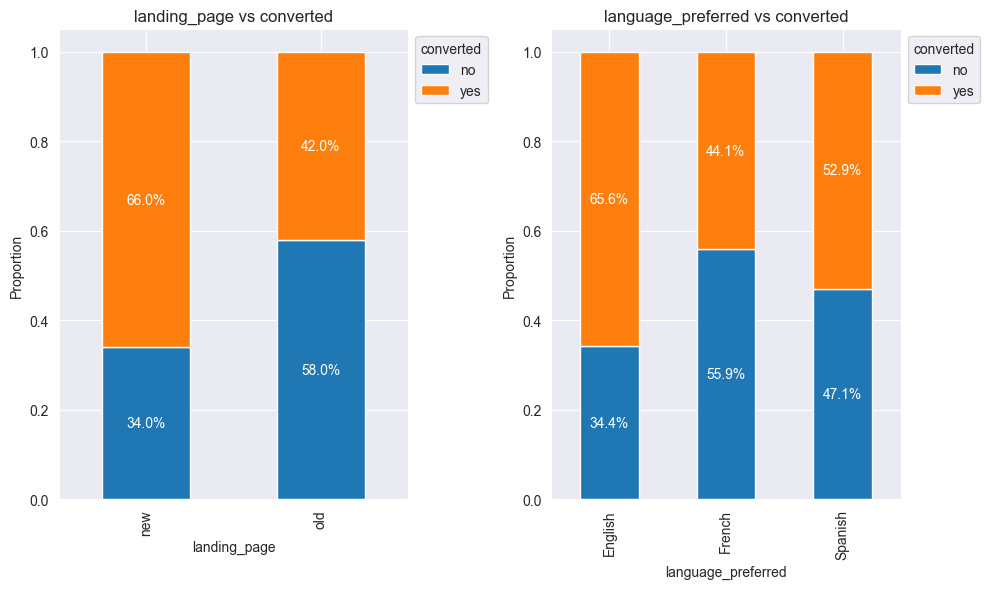

```python
# define the list of categorical features to plot against 'converted'
categories_v_converted = ['landing_page',  'language_preferred']

plt.figure(figsize=(10,6))
# call the function to plot crosstabs
bivariate_crosstab_plots(df, categories_v_converted, 'converted')
```

**Observations:**

- New landing_page has higher conversion (66%) than old page (42%)
  - Page design/version is likely influencing user action positively.
- Conversion varies by language_preferred
  - English highest (~66%), Spanish mid (~53%), French lowest (~44%)
  - Localization effectiveness differs but is less pronounced than page version effect.

### landing_page vs language_preferred

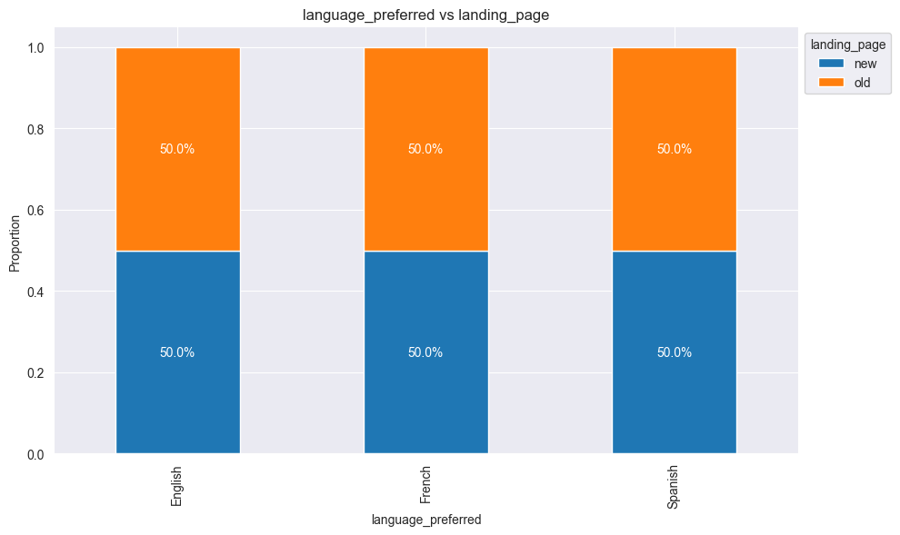

```python
# define the list of categorical features to plot against 'landing_page'
categories_v_landing_page = ['language_preferred']

plt.figure(figsize=(10,6))

# call the function to plot crosstabs
bivariate_crosstab_plots(df, categories_v_landing_page, 'landing_page')
```

```python
# Crosstab for landing_page vs language_preferred
pd.crosstab(df['language_preferred'], df['landing_page'])
```

| landing_page language_preferred | new | old |
| --- | --- | --- |
| English | 16 | 16 |
| French | 17 | 17 |
| Spanish | 17 | 17 |

**Observations :**

- Each language (English, French, Spanish) shows a 50% / 50% split between new and old landing pages.
- This indicates no observable difference in landing page assignment across languages i.e., the allocation appears perfectly balanced.
- Equal 50/50 splits across languages indicate successful randomization (or proper stratification), with no detectable language-induced assignment bias between page versions

### time_spent_on_the_page vs landing_page, language_preferred, converted

- We will plot boxplots for `time_spent_on_the_page` against `landing_page` and `language_preferred` columns to visualize the distribution of time spent across different categories

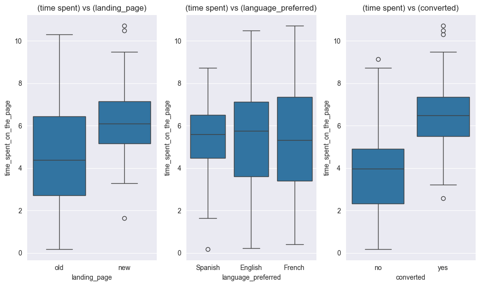

```python
# define the categorical features to plot against 'time_spent_on_the_page'
cat_features_v_time_spent = ['landing_page', 'language_preferred', 'converted']

feature_time_spent = 'time_spent_on_the_page'
# define the plot figure size
plt.figure(figsize=(10, 6))

# plotting the boxplots for each numerical feature
for i, feature in enumerate(cat_features_v_time_spent):
    plt.subplot(1, 3, i+1)    # assign a subplot in the main plot
    plt.title(f"(time spent) vs ({feature})")
    sns.boxplot(data=df, x=feature, y=feature_time_spent)    # plot the boxplot

plt.tight_layout()
plt.show()
```

**Observations:**

`time_spent` vs `converted`

- Converted = yes: higher median (~6.4) and upper distribution shifted right.
- Converted = no: lower median (~4.0) with more low time values.
- Clear upward shift indicates longer time_spent associates with conversion.
- Few Outliers are visible in converted = yes group above 10

**Key Inferences:**

- The new landing page likely increases user engagement (higher, more consistent time_spent).
- Greater time_spent is positively associated with conversion
- Language preference may be exerting minimal effect on time_spent

### time_spent_on_the_page vs landing_page, language_preferred, converted

- To further explore the relationship between `time_spent_on_the_page` and `landing_page`, with `language_preferred` as hue and `converted` as facets, we will use seaborn's `catplot`
- This will help visualize how time spent varies across landing pages, languages, and conversion status
- The `violin` kind will be used to show the distribution shape of time spent
- This visualization will provide insights into how these factors interact and influence user engagement on the landing pages

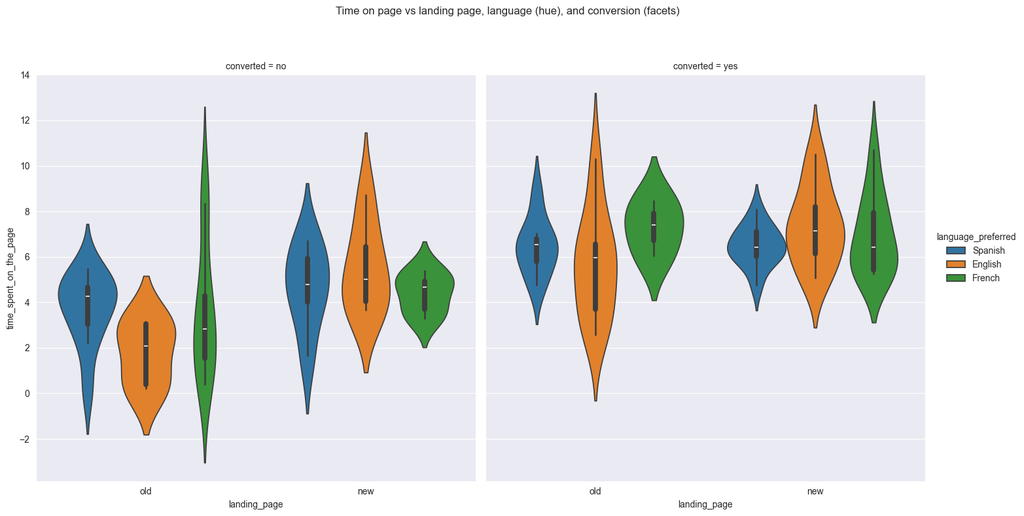

```python
# Using seaborn's catplot to create boxplots of time_spent_on_the_page vs landing_page
# with hue as language_preferred and separate panels for converted status
g = sns.catplot(
    data=df,
    x="landing_page",
    y="time_spent_on_the_page",
    hue="language_preferred",
    col="converted",          # separate panels for conversion yes/no
    kind="violin",               # use "violin" for distribution shape
    height=8,
    aspect=0.9
)

# Adjust the main title and layout
g.fig.subplots_adjust(top=0.85)
g.fig.suptitle("Time on page vs landing page, language (hue), and conversion (facets)")
# plt.tight_layout()
plt.show()
```

**Observations:**

`Facet converted` = no

- Old landing_page:
  - Spanish shows moderate distribution (center ~4–5)
  - English lowest time spent (center ~2)
  - French highly variable with a long upper tail reaching ~12+.
- New landing_page:
  - All languages cluster higher than English's old page
  - Spanish and English centers shift upward (~5)
  - French tight around ~4–5 with extremely reduced tail.

`Facet converted` = yes:

- Old landing_page:
  - All languages shift to higher times
  - French highest center (~7–8), Spanish ~6–7, English broader spread (~3–7).
- New landing_page:
  - English and Fremch exhibit higher upper tails (to ~10)
  - Spanish and French centers ~6–7 with similar spread.

**Across facets**

- Time_spent_on_the_page is consistently higher for converted = yes than converted = no for every language and page version.

**Page version effect**: The new page

- raises English user time noticeably (for both converted and not)
- reduces French variability among non-converters and
- maintains Spanish engagement

**Language differences:**

- English has the lowest times when not converted on the old page, but among converters on the new page English attains the highest upper tail.
- French converters on old page show strong concentration at high times.

**Distribution shape:**

- Non-converters display wider or skewed distributions (especially French old) versus more elevated, sometimes tighter distributions for converters.

# EDA Insights

- This section will illustrate the key insights derived from the exploratory data analysis (EDA) conducted on the E-news Express dataset.
- The insights will cover observations on individual variables as well as relationships between variables.

## Observations on Individual Variables

1. The dataset contains 100 rows and 6 columns with no missing or duplicate values.
2. Categorical columns (`group`, `landing_page`, `converted`, `language_preferred`)
3. Numerical column (`time_spent_on_the_page`)
4. Categorical columns show balanced distributions for `group` and `landing_page`, slight majority for `converted`, and near-uniform distribution for `language_preferred`.
5. Numerical column shows a roughly symmetric distribution with moderate spread and mild right skew.
6. No negative values in numerical column.
7. Descriptive statistics indicate a stable central tendency suitable for parametric tests.
8. Boxplots and histograms confirm the distribution characteristics of the numerical column.
9. Categorical columns show balanced distributions, enabling unbiased comparisons.
10. No reweighting or resampling needed before hypothesis tests.

## Observations on relationships between variables

1. New landing page shows higher conversion rates (66%) compared to the old page (42%).
2. Conversion rates vary by language preference, with English having the highest (66%), Spanish mid (53%), and French the lowest (44%).
3. Each language shows a balanced 50/50 split between new and old landing pages.
4. Time spent on the page is higher for the new landing page, with a higher median and tighter IQR.
5. Converted users spend more time on the page compared to non-converted users.
6. The new landing page likely increases user engagement and is positively associated with conversion
7. Language preference appears to have minimal effect on time spent compared to landing page version and conversion status.
8. Non converters display wider or skewed distributions versus more elevated, sometimes tighter distributions for converters.

# Utility function to compare p-value and print conclusion

```python
def compare_p_value_and_conclude(p_value_param, alpha=0.05):
    """
    Function to compare p-value with significance level and print conclusion.

    Parameters:
    p_value_param (float): The p-value from the statistical test.
    alpha (float): The significance level (default is 0.05).

    Returns:
    None
    """
    # print the conclusion based on p-value
    if p_value_param < alpha:
        print(f'As the p-value {p_value_param:.6f} is less than the level of significance, we reject the null hypothesis.')
    else:
        print(f'As the p-value {p_value_param:.6f} is greater than the level of significance, we fail to reject the null hypothesis.')
```

```python
# define the significance level
alpha = 0.05
```

# Question 1

> Do the users spend more time on the new landing page than on the existing landing page?

## Visual analysis

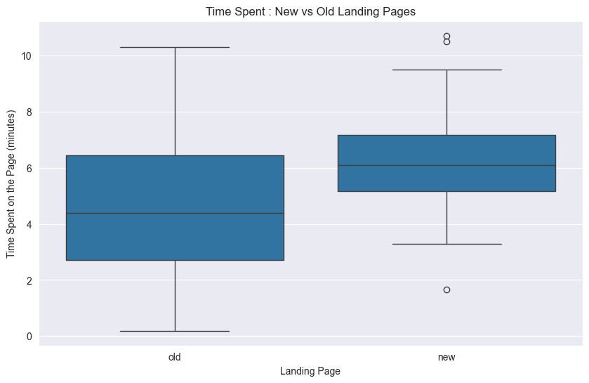

```python
# Boxplot of time_spent_on_the_page vs landing_page
plt.figure(figsize=(10, 6))
sns.boxplot(data=df, x='landing_page', y='time_spent_on_the_page')

# set plot title and labels
plt.title('Time Spent : New vs Old Landing Pages')
plt.xlabel('Landing Page')
plt.ylabel('Time Spent on the Page (minutes)')
plt.show()
```

**Conclusion:**

- Visual evidence suggests users spend more time on the new landing page compared to the old one.
- However, statistical testing is needed to confirm if this difference is significant.
- We will proceed with hypothesis testing to validate this observation.

## Hypothesis Formulation

Let $\mu_{new}$ and $\mu_{old}$ be the mean time spent on the new and old landing pages respectively.

> $H_0$ : The mean time spent on the new landing page is equal to that on the old landing page.

> $H_a$ : The mean time spent on the new landing page is greater than that on the old landing page.

Mathematically, the above formulated hypotheses can be stated as:

> $H_0 : \mu_{new}=\mu_{old}$

> $H_a : \mu_{new}>\mu_{old}$

We will test the null hypothesis

## Selecting the appropriate test

- This is a two-sample problem as the new and old landing page samples are independent of each other
- The standard deviations of the two populations are not known
- This is a case of one-tailed hypothesis testing concerning population means of two different populations (time spent on new and old landing pages), i.e., $\mu_{new}$ and $\mu_{old}$ respectively

Following test will be used:

> **`Two (independent) Sample t-test for Equality of Means`**

## Data collection and preparation

### Data preparation

- We will prepare the dataset for the two independent sample t-test for equality of means with unequal standard deviations
- The assumptions for this test will be validated in the next section

```python
# Create a DataFrame with time spent on new and old landing pages
time_spent_df = pd.DataFrame({
    'new_page_time': df[df['landing_page'] == 'new']['time_spent_on_the_page'].values,
    'old_page_time': df[df['landing_page'] == 'old']['time_spent_on_the_page'].values
})
time_spent_df
```

|  | new_page_time | old_page_time |
| --- | --- | --- |
| 0 | 7.13 | 3.48 |
| 1 | 4.40 | 3.02 |
| 2 | 4.75 | 5.28 |
| 3 | 5.25 | 6.53 |
| 4 | 10.71 | 2.08 |
| 5 | 5.86 | 6.21 |
| 6 | 6.03 | 2.58 |
| 7 | 6.27 | 8.72 |
| 8 | 8.73 | 0.40 |
| 9 | 3.65 | 10.30 |
| 10 | 7.02 | 3.88 |
| 11 | 6.18 | 2.66 |
| 12 | 4.39 | 7.03 |
| 13 | 9.49 | 4.05 |
| 14 | 7.81 | 4.28 |
| 15 | 5.41 | 3.52 |
| 16 | 1.65 | 5.39 |
| 17 | 7.16 | 4.52 |
| 18 | 7.16 | 4.46 |
| 19 | 3.91 | 8.50 |
| 20 | 5.37 | 3.13 |
| 21 | 7.23 | 6.04 |
| 22 | 8.08 | 0.19 |
| 23 | 10.50 | 8.46 |
| 24 | 5.65 | 1.92 |
| 25 | 6.47 | 8.02 |
| 26 | 6.41 | 0.22 |
| 27 | 8.30 | 4.71 |
| 28 | 6.01 | 0.93 |
| 29 | 6.79 | 1.81 |
| 30 | 7.27 | 7.40 |
| 31 | 6.70 | 9.15 |
| 32 | 5.42 | 4.18 |
| 33 | 5.08 | 5.47 |
| 34 | 7.46 | 5.96 |
| 35 | 3.88 | 6.60 |
| 36 | 9.12 | 4.75 |
| 37 | 4.68 | 2.23 |
| 38 | 5.26 | 0.40 |
| 39 | 5.74 | 4.87 |
| 40 | 6.71 | 6.57 |
| 41 | 3.68 | 1.44 |
| 42 | 3.30 | 3.21 |
| 43 | 5.40 | 2.90 |
| 44 | 8.47 | 4.30 |
| 45 | 4.94 | 0.91 |
| 46 | 5.15 | 6.04 |
| 47 | 7.07 | 8.35 |
| 48 | 6.20 | 3.05 |
| 49 | 5.86 | 6.52 |

```python
# find the sample means and sample standard deviations for the two samples
mean_new = time_spent_df['new_page_time'].mean()
mean_old = time_spent_df['old_page_time'].mean()
std_new = time_spent_df['new_page_time'].std()
std_old = time_spent_df['old_page_time'].std()

# print the sample means and standard deviations
print(f"Mean time spent on new page: {mean_new:.2f} minutes")
print(f"Mean time spent on old page: {mean_old:.2f} minutes")
print(f"Standard deviation of time spent on new page: {std_new:.2f} minutes")
print(f"Standard deviation of time spent on old page: {std_old:.2f} minutes")
```

```
Mean time spent on new page: 6.22 minutes
Mean time spent on old page: 4.53 minutes
Standard deviation of time spent on new page: 1.82 minutes
Standard deviation of time spent on old page: 2.58 minutes
```

### Validate T-test assumptions

We will validate the assumptions for using a `Two Independent Sample T-test for Equality of Means - Unequal Std Dev`

- Continuous Data
  - Yes, `time_spent_on_the_page` is measured in minutes and is continuous.
- Normally distributed populations
  - Sample Size: n1=n2=50 (Central Limit Theorem applies, so normality assumption is reasonable).
  - Visual Check: Histograms and box plots show roughly symmetric distributions with a mild right skew and no extreme outliers.
  - Conclusion: Normality assumption is reasonably satisfied.
- Independent populations
  - As we are taking samples for two different landing pages (new and old), the two samples are from two independent populations.
- Unequal population standard deviations
  - The sample standard deviations are 1.82 minutes and 2.58 minutes for new and old pages respectively.
  - As the sample standard deviations are different, the population standard deviations may be assumed to be different.
- Random sampling from the population
  - Yes, we are informed that the collected sample a simple random sample and the sample observations are independent of each other.

## Calculating the p-value

- This calculation uses the [ttest_ind](https://docs.scipy.org/doc/scipy-1.16.0/reference/generated/scipy.stats.ttest_ind.html) function from the `scipy.stats` module to perform the two independent sample t-test for equality of means with unequal standard deviations

```python
# find the p-value by passing the two samples to the ttest_ind function
# alternative is  'greater' to perform one-sided test
# equal_var as False to account for unequal standard deviations
ttest_result = ttest_ind(time_spent_df['new_page_time'], time_spent_df['old_page_time'].dropna(), equal_var = False, alternative = 'greater')
ttset_p_value = ttest_result.pvalue
ttest_stat = ttest_result.statistic
degrees_of_freedom = ttest_result.df

# calculate critical t-value for alpha=0.05
t_critical = t.ppf(1 - alpha, degrees_of_freedom)

# print the one-sided p-value for the test
print(f'One-sided p-value: {ttset_p_value:.6f}')

# print test statistic
print(f'Test Statistic: {ttest_stat:.4f}')

# print degrees of freedom
print(f'Degrees of Freedom: {degrees_of_freedom:.2f}')

# print the critical t-value
print(f'Critical t-value at alpha={alpha}: {t_critical:.4f}')
```

```
One-sided p-value: 0.000139
Test Statistic: 3.7868
Degrees of Freedom: 87.97
Critical t-value at alpha=0.05: 1.6624
```

### Visualizing the rejection region and test statistic

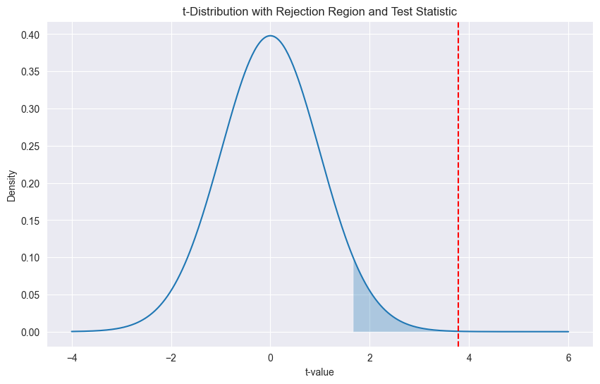

```python
# Visualizing the rejection region, and test statistic
x = np.linspace(-4, 6, 400)
y = t.pdf(x, degrees_of_freedom)

plt.figure(figsize=(10, 6))
plt.plot(x, y)

# Shade rejection region
xr = np.linspace(t_critical, 6, 200)
plt.fill_between(xr, t.pdf(xr, degrees_of_freedom), alpha=0.3)

# Mark test statistic as red line
plt.axvline(ttest_stat, color='red', linestyle='--', label='Test Statistic')

# Labels
plt.title("t-Distribution with Rejection Region and Test Statistic")
plt.xlabel("t-value")
plt.ylabel("Density")

plt.show()
```

- From the plot above, we can see that the test statistic falls in the rejection region
- This indicates that we have enough evidence to reject the null hypothesis
- We will proceed to compare the p-value with the significance level to draw conclusions regarding the null hypothesis

## Inference based on p-value

- p-value will be compared with the significance level $\alpha$ of 0.05 to draw conclusions regarding the null hypothesis.

```python
# compare p-value with significance level and print conclusion
compare_p_value_and_conclude(ttset_p_value, alpha=0.05)
```

```
As the p-value 0.000139 is less than the level of significance, we reject the null hypothesis.
```

### Analysis

- The p-value is ~0.000139
- This p-value is less than the significance level of 0.05

### Conclusion

> We reject the null hypothesis $H_0 : \mu_{new}=\mu_{old}$

> We have enough statistical evidence to conclude that the mean time spent on the new landing page is greater than the mean time spent on the old landing page.

### Business Inference

- Users spend significantly more time on the new landing page compared to the old landing page.
- The new page is more engaging for users overall.

# Question 2

> Is the conversion rate (the proportion of users who visit the landing page and get converted) for the new page greater than the conversion rate for the old page?

## Visual analysis

**Conversion Rate:**

- Conversion rate is the proportion of users who visit the landing page and get converted.
- For example, if out of 50 users, 20 gets converted. Then the conversion rate is 20/50 =0.4

```python
# compute the conversion rates for new and old landing pages for only converted users i.e., for converted = yes
conversion_rates =conversion_rates = (
    df[df['converted'] == 'yes']
    .groupby('landing_page')
    .size()
    .div(df.groupby('landing_page').size())
    .rename('conversion_rate')
)
# display the conversion rates
conversion_rates
```

```
landing_page
new    0.66
old    0.42
Name: conversion_rate, dtype: float64
```

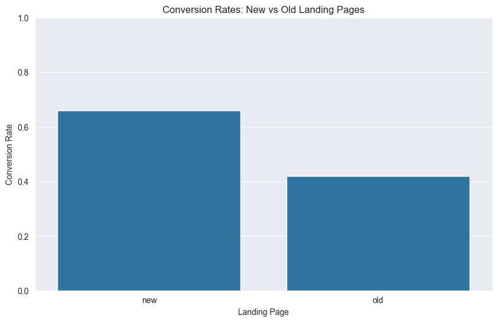

```python
# Plot the conversion rates for new and old landing pages
plt.figure(figsize=(10, 6))

# plotting the barplot for conversion rates
sns.barplot(x=conversion_rates.index, y=conversion_rates.values)

# add title and labels
plt.title('Conversion Rates: New vs Old Landing Pages')
plt.xlabel('Landing Page')
plt.ylabel('Conversion Rate')

# limit y-axis from 0 to 1
plt.ylim(0, 1)
plt.show()
```

**Observation:**

- New landing page has a conversion rate of 66% (33 out of 50 users converted).
- Old landing page has a conversion rate of 42% (21 out of 50 users converted).
- The conversion rate for the new landing page is significantly higher than that for the old landing page.
- This suggests that the new landing page is more effective in converting users compared to the old landing page.

**Note :**

- However, statistical testing is needed to confirm if this difference is significant.
- We will proceed with hypothesis testing to validate this observation.

## Hypothesis Formulation

- `conversion` and the `landing_page` are the 2 categorical variables of interest here.
- We will formulate the null and alternative hypotheses for the conversion rates of the new and old landing

Let $p_{new}$ be the conversion proportion for the new landing page and $p_{old}$ for the old landing page.

> $H_0$ : The conversion rate for the new landing page is equal to that for the old landing page.

> $H_a$ : The conversion rate for the new landing page is greater than that for the old landing page.

Mathematically, the above formulated hypotheses can be stated as:

> $H_0 : p_{new}=p_{old}$

> $H_a : p_{new} > p_{old}$

We will test the null hypothesis

## Selecting the appropriate test

- The formulated hypotheses are concerned with proportions.
- This is a one-tailed test, concerning two population proportions $p_{new}$ and $p_{old}$, the proportion of users who get converted on the new and old landing pages respectively
- The samples for new and old landing pages are independent of each other
- A test of proportions can be used to analyse the hypotheses and draw a conclusion. We shall use a Proportions Z test for this problem.

Following test will be used:

> **`Two-Proportions Z-Test`**

### Significance of the test

- Test for equality of 2-population proportions $H_0 : p_{new}=p_{old}$

### Assumptions

- Binomially distributed populations
- Independent populations
- Random sampling from the populations
- When both mean (np) and n(1-p) are greater than or equal to 10, the binomial distribution can be approximated by a normal distribution

### Test Statistic Distribution

- Standard Normal distribution (Z distribution)
- This test is also known as, Two independent sample Z-test for proportions

## Data collection and preparation

### Data preparation

```python
# compute the new page subscribers
new_page_subscribers = df[(df['landing_page'] == 'new') & (df['converted'] == 'yes')].shape[0]

# compute the old page subscribers
old_page_subscribers = df[(df['landing_page'] == 'old') & (df['converted'] == 'yes')].shape[0]

# compute the total number of users for new and old landing pages
n_new = df[df['landing_page'] == 'new'].shape[0]
n_old = df[df['landing_page'] == 'old'].shape[0]

# print the number of subscribers for new and old landing pages wrto total users
print(f"New page subscribers: {new_page_subscribers} out of total {n_new} new page users")
print(f"Old page subscribers: {old_page_subscribers} out of total {n_old} old page users")
```

```
New page subscribers: 33 out of total 50 new page users
Old page subscribers: 21 out of total 50 old page users
```

### Validate test assumptions

We will validate the assumptions for using a `Two-Proportions Z-Test`

- Binomially distributed populations
  - The `converted` variable denotes whether a user subscribes or not (yes/no), which is a binary outcome.
- Independent populations
  - The samples for new and old landing pages are independent of each other as users are randomly assigned to either page.
- Random sampling from the populations
  - Yes, we are informed that the collected sample is a simple random sample and the sample observations are independent of each other.
- Normal approximation to the binomial : When both mean (np) and n(1-p) are greater than or equal to 10, the binomial distribution can be approximated by a normal distribution For new page:

> $np_{new} = 50\cdot \frac{33}{50} =33 \geq 10$

> $n(1-p_{new}) = 50 \cdot \frac{50-33}{50} =17 \geq 10 $

For old page:

> $np_{old} = 50\cdot \frac{21}{50} =21 \geq 10$

> $n(1-p_{old}) = 50 \cdot \frac{50-21}{50} =29 \geq 10 $

Since all values are greater than or equal to 10, the normal approximation is valid.

## Calculating the p-value

- This test uses the same [`proportions_ztest()`](https://www.statsmodels.org/devel/generated/statsmodels.stats.proportion.proportions_ztest.html) function for comparing two proportions.

```python
# set the counts of defective items
subscriber_counts = np.array([new_page_subscribers, old_page_subscribers])

# set the sample sizes
sample_sizes = np.array([n_new, n_old])

# find the p-value by passing the counts and sample sizes to the proportions_ztest function
# setting alternative as 'larger' for one-sided test
ztest_stat, ztest_p_value  = proportions_ztest(subscriber_counts, sample_sizes, alternative = 'larger')

# calculate critical z-value for alpha=0.05
z_critical = norm.ppf(1 - alpha)

# print the p-value for the test
print(f'p-value for the proportions z-test: {ztest_p_value:.6f}')

# print test statistic
print(f'Test Statistic: {ztest_stat:.4f}')

# print the critical z-value
print(f'Critical z-value at alpha={alpha}: {z_critical:.4f}')
```

```
p-value for the proportions z-test: 0.008026
Test Statistic: 2.4077
Critical z-value at alpha=0.05: 1.6449
```

### Visualizing the rejection region and test statistic

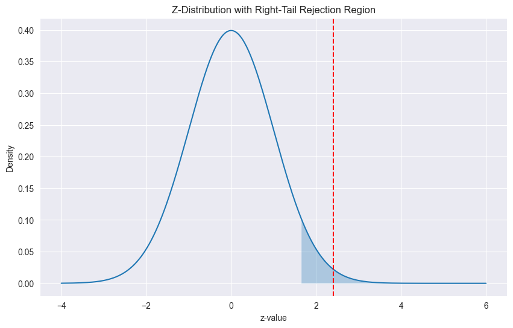

```python
# Visualizing the rejection region, and test statistic
x = np.linspace(-4, 6, 400)
y = norm.pdf(x)

# define the plot figure size
plt.figure(figsize=(10, 6))
plt.plot(x, y)

# Shade rejection region
xr = np.linspace(z_critical, 6, 200)
plt.fill_between(xr, norm.pdf(xr), alpha=0.3)

# Mark test statistic as red line
plt.axvline(ztest_stat, color='red', linestyle='--', label='Test Statistic')

plt.title("Z-Distribution with Right-Tail Rejection Region")
plt.xlabel("z-value")
plt.ylabel("Density")
plt.show()
```

- From the plot above, we can see that the test statistic falls in the rejection region
- This indicates that we have enough evidence to reject the null hypothesis
- We will proceed to compare the p-value with the significance level to draw conclusions regarding the null hypothesis

## Inference based on p-value

- p-value will be compared with the significance level $\alpha$ of 0.05 to draw conclusions regarding the null hypothesis.

```python
# compare p-value with significance level and print conclusion
compare_p_value_and_conclude(ztest_p_value, alpha=0.05)
```

```
As the p-value 0.008026 is less than the level of significance, we reject the null hypothesis.
```

### Analysis

- The p-value is ~0.008026
- The p-value is less than the significance level of 0.05

### Conclusion

> We reject the null hypothesis $H_0 : p_{new}=p_{old}$

> We have enough statistical evidence to conclude that the conversion rate for the new landing page is greater than that for the old landing page.

### Business Inference

- The new landing page design positively influences user behavior towards conversion.
- Adopting the new landing page can enhance user engagement and drive better conversion performance.

# Question 3

> Does the converted status depend on the preferred language?

## Visual Analysis

we will plot the crosstab of `language_preferred` vs `converted` to visualize the relationship between preferred language and conversion status. This will help us understand if there is any apparent dependence between these two categorical variables

```python
# Crosstab with counts and a per-language total column
language_converted_ct = pd.crosstab(df['language_preferred'], df['converted'])
language_converted_ct['total'] = language_converted_ct.sum(axis=1)
language_converted_ct
```

| converted language_preferred | no | yes | total |
| --- | --- | --- | --- |
| English | 11 | 21 | 32 |
| French | 19 | 15 | 34 |
| Spanish | 16 | 18 | 34 |

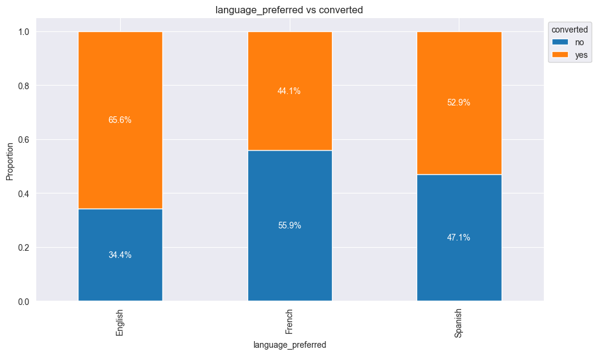

```python
# define the list of categorical features to plot against 'converted'
lang_v_converted_ct = ['language_preferred']

# call the function to plot cross-tabs
bivariate_crosstab_plots(df, lang_v_converted_ct, 'converted')
```

**Analysis**

- English has the highest conversion rate (about 66% i.e., 21/32) among the three languages.
- French has the lowest conversion rate (about 44% i.e., 15/34), with a majority of users not converting.
- Spanish has a mid-level conversion rate (about 53% i.e., 18/34).

**Interpretation**

- Conversion proportion varies by language preference
  - English users convert more
  - French users less
  - Spanish users in between.
- This suggests a potential association between `language_preferred` and `converted` that warrants a test of independence in subsequent analysis.

**Note:**

- However, statistical testing is needed to confirm if this dependence is significant.
- We will proceed with hypothesis testing to validate this observation.

## Hypothesis Formulation

- `language_preferred` and `converted` are the 2 independent categorical variables of interest here.
- We will formulate the null and alternative hypotheses for the dependence between the converted status and preferred language.

> $H_0$ : Converted status is independent of the preferred language.

> $H_a$ : Converted status is dependent on the preferred language.

We will test the null hypothesis

## Selecting the appropriate test

- This is a problem concering the independence of two categorical variables, `language_preferred` (English / French / Spanish) and `converted` (Yes / No)
- A Chi-Square test of independence can be used to analyse the hypotheses and draw a conclusion. We shall use a Chi-Square test of independence for this problem.

Following test will be used:

> **`Chi-Square Test of Independence`**

### Significance of the test

In a contingency table,

> $H_0$ : The row and column variables are independent

### Assumptions

- Categorical variables
- Expected value of the number of sample observations in each level of the variable is at least 5
- Random sampling from the population

### Test Statistic Distribution

- Chi-Square distribution
- This test is also known as, **Chi-Square test of independence**

## Data Collection and Preparation

### Data Preparation

**Contingency Table:**

- To perform the Chi-squared test of independance we need to create the contingency table.
- A contingency table is a tabular representation of categorical data.
- A contingency table shows the number of observations for combinations of values between two categorical variables, say X and Y. Each cell in the contingency table represents a combination of X-Y values.
- The pandas [crosstab()](https://pandas.pydata.org/docs/reference/api/pandas.crosstab.html) function is used to create a contingency table between two categorical variables from a dataframe.

```python
# create the contingency table showing the distribution of the two categorical variables
subscribers_contingency_table = pd.crosstab(df['language_preferred'], df['converted'])
subscribers_contingency_table
```

| converted language_preferred | no | yes |
| --- | --- | --- |
| English | 11 | 21 |
| French | 19 | 15 |
| Spanish | 16 | 18 |

### Validate test assumptions

We will validate the assumptions for using a `Chi-Square Test of Independence`

- Categorical variables : Satisfied
  - Both `language_preferred` and `converted` are categorical variables
  - The row and column variables in the contingency table are independent categorical variables.
- Expected value of the number of sample observations in each level of the variable is at least 5 : Satisfied
  - The contingency table shows that all expected counts are greater than 5 (ranging from 15 to 21 for yes and 11 to 19 for no).
- Random sampling from the population : Satisfied
  - Yes, we are informed that the collected sample is a simple random sample and the sample observations are independent of each other.

## Calculating the p-value

- The [chi2_contingency](https://docs.scipy.org/doc/scipy/reference/generated/scipy.stats.chi2_contingency.html) function from the `scipy.stats` module is used to perform the Chi-Square test of independence and calculate the p-value.

```python
# use chi2_contingency() to find the p-value
chi, chi2_p_value, chi2_dof, expected = chi2_contingency(subscribers_contingency_table)

# calculate critical chi-square value for alpha=0.05
chi2_critical = chi2.ppf(1 - alpha, chi2_dof)

# print test statistic for the chi-square test
print(f'Test Statistic: {chi:.4f}')

# print the degrees of freedom
print(f'Degrees of Freedom: {chi2_dof}')

# print the critical chi-square value
print(f'Critical chi-square value at alpha={alpha}: {chi2_critical:.4f}')

# print the p-value for the test
print(f'p-value for the Chi-Square test of independence: {chi2_p_value:.6f}')
```

```
Test Statistic: 3.0930
Degrees of Freedom: 2
Critical chi-square value at alpha=0.05: 5.9915
p-value for the Chi-Square test of independence: 0.212989
```

### Visualizing the rejection region, and test statistic

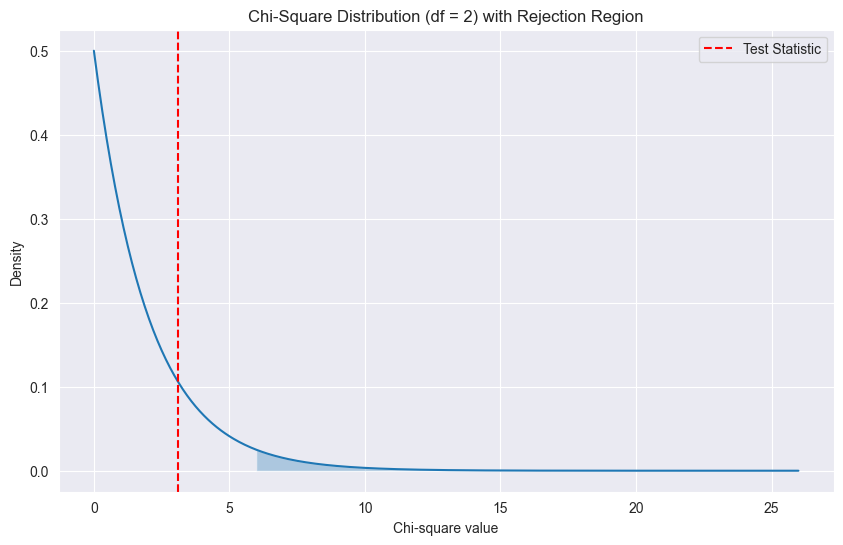

```python
# Draw Chi-square distribution
x = np.linspace(0, chi2_critical + 20, 500)       # goes far enough to see tail
y = chi2.pdf(x, chi2_dof)

plt.figure(figsize=(10, 6))
plt.plot(x, y)

# Shade rejection region
xr = np.linspace(chi2_critical, x.max(), 300)
plt.fill_between(xr, chi2.pdf(xr, chi2_dof), alpha=0.3)

# Mark test statistic
plt.axvline(chi, color='red', linestyle='--', label="Test Statistic")

plt.title(f"Chi-Square Distribution (df = {chi2_dof}) with Rejection Region")
plt.xlabel("Chi-square value")
plt.ylabel("Density")
plt.legend()
plt.show()
```

- From the plot above, we can see that the test statistic is not in the rejection region
- This indicates that we do not have enough evidence to reject the null hypothesis
- We will proceed to compare the p-value with the significance level to draw conclusions regarding the null hypothesis

## Inference based on p-value

- p-value will be compared with the significance level $\alpha$ of 0.05 to draw conclusions regarding the null hypothesis.

```python
# compare p-value with significance level and print conclusion
compare_p_value_and_conclude(chi2_p_value, alpha=0.05)
```

```
As the p-value 0.212989 is greater than the level of significance, we fail to reject the null hypothesis.
```

### Analysis

- The p-value is ~0.212989
- This p-value is greater than the significance level of 0.05
- There is insufficient evidence to suggest a dependence between converted status and preferred language.

### Conclusion

> We fail to reject the null hypothesis $H_0$ : Converted status is independent of the preferred language.

> We do not have enough statistical evidence to conclude that the converted status depends on the preferred language.

### Business Inference

- The preferred language of users does not significantly influence their conversion status.
- The results could be interpreted to mean that language preference alone is not a determining factor for conversion, and other factors may play a more significant role in influencing user conversion behavior.

# Question 4

> Is the time spent on the new page the same for the different language users?

## Visual Analysis

- Here `time_spent_on_the_page` is the response and `language_preferred` by group is the factor.
- We will plot boxplots for `time_spent_on_the_page` against `language_preferred` for new group to visualize the distribution of time spent across different language preferences
- This will help us understand if there are any apparent differences in time spent among new page users with different language preferences

```python
# filter dataset by new landing page
new_page_df = df[df['landing_page'] == 'new']

# get the page visit count by language preferred
page_visit_count_by_language = new_page_df['language_preferred'].value_counts()
page_visit_count_by_language
```

```
language_preferred
Spanish    17
French     17
English    16
Name: count, dtype: int64
```

```python
# mean time spent on new landing page by language preferred
print(new_page_df.groupby("language_preferred")["time_spent_on_the_page"].mean())
```

```
language_preferred
English    6.663750
French     6.196471
Spanish    5.835294
Name: time_spent_on_the_page, dtype: float64
```

```python
# descriptive statistics of time spent on new landing page by language preferred
new_page_df.groupby("language_preferred")['time_spent_on_the_page'].describe()
```

| language_preferred | count | mean | std | min | 25% | 50% | 75% | max |
| --- | --- | --- | --- | --- | --- | --- | --- | --- |
| English | 16.0 | 6.663750 | 1.984150 | 3.65 | 5.3275 | 6.865 | 7.7125 | 10.50 |
| French | 17.0 | 6.196471 | 1.933394 | 3.30 | 5.2500 | 5.420 | 7.2700 | 10.71 |
| Spanish | 17.0 | 5.835294 | 1.525656 | 1.65 | 5.1500 | 6.200 | 6.7000 | 8.08 |

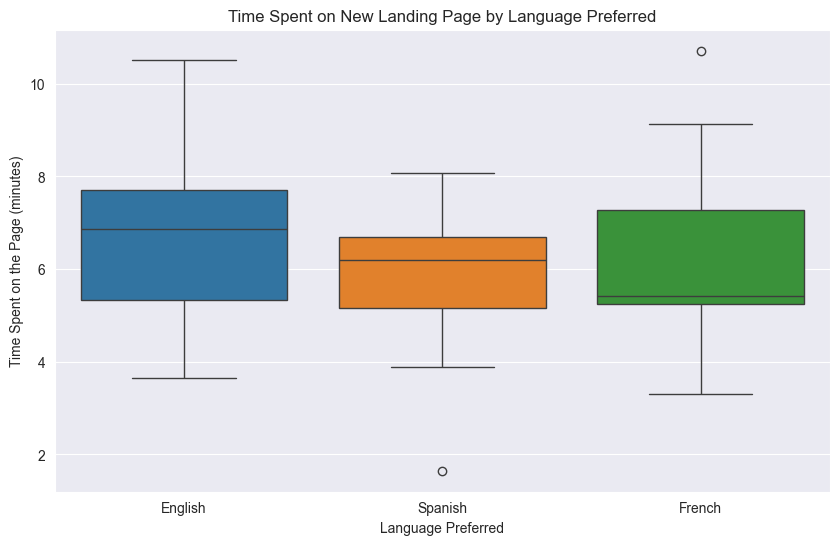

```python
# plot boxplot of time_spent_on_the_page vs language_preferred for new landing page
plt.figure(figsize=(10, 6))
sns.boxplot(data=new_page_df, x='language_preferred', y='time_spent_on_the_page', hue='language_preferred')

# set plot title and labels
plt.title('Time Spent on New Landing Page by Language Preferred')
plt.xlabel('Language Preferred')
plt.ylabel('Time Spent on the Page (minutes)')
plt.show()
```

### Analysis

**Numerical observations**

- Mean ordering: Larger gap of 0.83 in mean exist between English and Spanish
  - English (6.66) > French (6.20) > Spanish (5.84)
- Median ordering: English has the highest median time spent, followed by Spanish and French
  - English (6.865) > Spanish (6.200) > French (5.420)
  - Median spread between highest and lowest is approx 1.445.
- IQRs: There is a moderate overlap among all 3 languages
  - English 2.385; French 2.020; Spanish 1.550
- Ranges: French has the widest range, Spanish the narrowest
  - French 7.41; English 6.85; Spanish 6.43
  - wide ranges also driven by high/low outliers
- Outliers (visual): Very few outliers
  - High values near 10.5 to 10.7 for English/French
  - low value 1.65 for Spanish

**Visual interpretations**

- Boxplots show substantial overlap of middle 50% across languages.
- Differences in means and medians are modest relative to within‑group spread.
- No strong separation and variability patterns are similar.

**Inference** *(before test result)*

- The visual and descriptive evidence does not suggest a pronounced difference in mean time spent among language groups.

## Hypothesis Formulation

Let $\mu_{en},\ \mu_{fr},\ \mu_{es}$ be the means of time spent on the new landing page for English, French, and Spanish language users respectively.

> $H_0$: Means are equal across language preferred groups. i.e., $\mu_{en} = \mu_{fr} = \mu_{es}$

> $H_a$: At least one mean differs among language preferred groups.

## Selecting the appropriate test

- Here we will compare the means of more than two independent groups (English, French, Spanish) for a continuous response variable (time spent on the new landing page).
- The standard deviations of the populations are not known
- This is a case of one-way ANOVA (Analysis of Variance) test concerning population means of more than two different populations (time spent on new landing page by different language preferred users), i.e., $\mu_{en},\ \mu_{fr},\ \mu_{es}$ respectively

Following test will be used:

> **`One-Way ANOVA Test`**

### Significance of the test

- Test for means for more than two populations. $H_0$ : All population means are equal

### Assumptions

- The populations are normally distributed
- Samples are independent simple random samples
- Population variances are equal

### Test Statistic Distribution

- F distribution (The test is also known as One-way ANOVA F-test)

## Data Collection and Preparation

The normality and equality of variance assumptions need to be checked.

1. For testing of normality, Shapiro-Wilk’s test is applied to the response variable.
2. For equality of variance, Levene test is applied to the response variable.

### Shapiro-Wilk’s test

against the alternative hypothesis

> $H_a:$ Time spent on the page is not normally distributed for at least one language group on the new landing page

**Note** : The [`shapiro()`](https://docs.scipy.org/doc/scipy/reference/generated/scipy.stats.shapiro.html) function of Scipy will be used to compute the test statistic and p-value.

```python
# Assumption 1: Normality
# find the p-value using shapiro() function
w, shapiro_p_value = shapiro(new_page_df['time_spent_on_the_page'])

# print the p-value for the test
print(f'p-value for Shapiro-Wilk test: {shapiro_p_value:.6f}')
```

```
p-value for Shapiro-Wilk test: 0.804004
```

- The p-value is 0.804004 which is greater than the significance level of 0.05
- We fail to reject the null hypothesis that the response variable follows a normal distribution

### Levene’s test

We will test the null hypothesis

> $H_0$: All the population variances of time spent on the new landing page are equal across different language preferred groups

against the alternative hypothesis

> $H_a$: At least one population variance of time spent on the new landing page differs across different language preferred groups

The [`levene()`](https://docs.scipy.org/doc/scipy/reference/generated/scipy.stats.shapiro.html) function of Scipy will be used to compute the test statistic and p-value.

```python
#Assumption 2: Homogeneity of Variance
# find the p-value using levene() function
statistic, levene_p_value = levene(
    new_page_df[new_page_df['language_preferred'] == 'English']['time_spent_on_the_page'],
    new_page_df[new_page_df['language_preferred'] == 'French']['time_spent_on_the_page'],
    new_page_df[new_page_df['language_preferred'] == 'Spanish']['time_spent_on_the_page']
)

# print the p-value for the levene test
print(f'p-value for Levene test: {levene_p_value:.6f}')
```

```
p-value for Levene test: 0.467114
```

- The p-value is 0.467114 which is greater than the significance level of 0.05
- Since the p-value is large, we fail to reject the null hypothesis of homogeneity of variances.

### Validate test assumptions

Now we will validate the assumptions for using a `One-Way ANOVA Test`

1. The populations are normally distributed : Satisfied
   - The p-value from Shapiro-Wilk’s test is 0.804004 which is greater than the significance level of 0.05
   - Hence, the normality assumption is verified using Shapiro-Wilk’s test.
2. Samples are independent simple random samples : Satisfied
   - Yes, we are informed that the collected sample is a simple random sample and the sample observations are independent of each other.
3. Population variances are equal : Satisfied
   - The p-value from Levene’s test is 0.467114 which is greater than the significance level of 0.05
   - Hence, the equality of variance assumption is verified using Levene’s test.

## Calculating the p-value

- The [`f_oneway()`](https://docs.scipy.org/doc/scipy/reference/generated/scipy.stats.f_oneway.html) function of Scipy will be used to compute the test statistic and p-value.

```python
# perform one-way anova test
f_test_stat, anova_p_value = f_oneway(
    new_page_df[new_page_df['language_preferred'] == 'English']['time_spent_on_the_page'],
    new_page_df[new_page_df['language_preferred'] == 'French']['time_spent_on_the_page'],
    new_page_df[new_page_df['language_preferred'] == 'Spanish']['time_spent_on_the_page'])

# print the p-value for the test
print(f'p-value for One-Way ANOVA test: {anova_p_value:.6f}')
```

```
p-value for One-Way ANOVA test: 0.432041
```

```python
# calculate degrees of freedom by defining groups
groups = [
    new_page_df[new_page_df['language_preferred'] == 'English']['time_spent_on_the_page'],
    new_page_df[new_page_df['language_preferred'] == 'French']['time_spent_on_the_page'],
    new_page_df[new_page_df['language_preferred'] == 'Spanish']['time_spent_on_the_page']
]

# k is number of groups
k = len(groups)

# N is total number of observations
N = sum(len(g) for g in groups)

# degrees of freedom
f_df1 = k - 1
f_df2 = N - k

# compute critical f-value for alpha=0.05
f_critical = f.ppf(1 - alpha, f_df1, f_df2)

print(f"F-statistic: {f_test_stat:.4f}")
print(f"Degrees of freedom: df1={f_df1}, df2={f_df2}")
print(f"Critical F-value: {f_critical:.4f}")
print(f"P-value: {anova_p_value:.6f}")
```

```
F-statistic: 0.8544
Degrees of freedom: df1=2, df2=47
Critical F-value: 3.1951
P-value: 0.432041
```

### Visualizing the rejection region, and test statistic

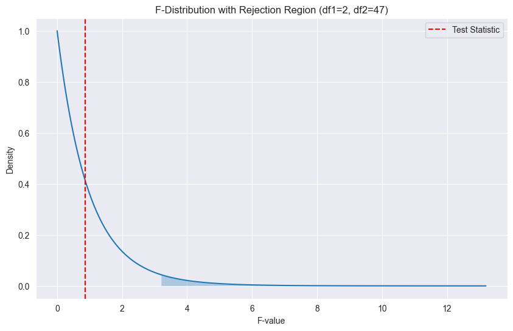

```python
# Plot F-distribution
x = np.linspace(0, f_critical + 10, 500)
y = f.pdf(x, f_df1, f_df2)

plt.figure(figsize=(10, 6))
plt.plot(x, y)

# Shade rejection region (right tail)
xr = np.linspace(f_critical, x.max(), 300)
plt.fill_between(xr, f.pdf(xr, f_df1, f_df2), alpha=0.3)

# Mark test statistic
plt.axvline(f_test_stat, color='red', linestyle='--', label="Test Statistic")

plt.title(f"F-Distribution with Rejection Region (df1={f_df1}, df2={f_df2})")
plt.xlabel("F-value")
plt.ylabel("Density")
plt.legend()
plt.show()
```

- From the plot above, we can see that the test statistic is not in the rejection region
- This indicates that we do not have enough evidence to reject the null hypothesis
- We will proceed to compare the p-value with the significance level to draw conclusions regarding the null hypothesis

## Inference based on p-value

- p-value will be compared with the significance level $\alpha$ of 0.05 to draw conclusions regarding the null hypothesis.

```python
# compare p-value with significance level and print conclusion
compare_p_value_and_conclude(anova_p_value, alpha=0.05)
```

```
As the p-value 0.432041 is greater than the level of significance, we fail to reject the null hypothesis.
```

### Analysis

- F-test p-value is 0.432041. This is greater than the significance level of 0.05
- Hence, there is insufficient evidence of differences in mean time spent among language preferred groups on the new landing page.
- This was also suggested by the visual and descriptive analysis earlier using boxplots and summary statistics.

### Conclusion

> We fail to reject the null hypothesis $H_0$: Means are equal across language preferred groups. i.e., $\mu_{en} = \mu_{fr} = \mu_{es}$

> We do not have enough statistical evidence to conclude that the time spent on the new page differs among users with different language preferences.

### Business Inference

- Time engagement on the new page is comparable across languages; no language-specific adjustment needed for increasing dwell time.
- Focus could be on optimization on universal page features and not language-specific tweaks.

# Summary of Hypothesis Test Results

```python
# Table with all the hypothesis, p-values and conclusions
hypothesis_results = pd.DataFrame({
    'Hypothesis': [
        'Mean time on new page > Mean time on old page',
        'Conversion rate new page > Conversion rate old page',
        'Converted status independent of preferred language',
        'Mean time on new page same across languages'
    ],
    'test-statistic': [
        'Two Independent Sample T-test for Equality of Means - Unequal Std Dev',
        'Two-Proportions Z-Test',
        'Chi-Square Test of Independence',
        'One-Way ANOVA Test'
    ],
    'p-value': [
        ttset_p_value,
        ztest_p_value,
        chi2_p_value,
        anova_p_value
    ],
    'Conclusion': [
        'Reject H0',
        'Reject H0',
        'Fail to Reject H0',
        'Fail to Reject H0'
    ]
})

hypothesis_results.style.set_properties(**{
    'white-space': 'normal',
    'text-align': 'left'
})

hypothesis_results
```

|  | Hypothesis | test-statistic | p-value | Conclusion |
| --- | --- | --- | --- | --- |
| 0 | Mean time on new page > Mean time on old page | Two Independent Sample T-test for Equality of Means - Unequal Std Dev | 0.000139 | Reject H0 |
| 1 | Conversion rate new page > Conversion rate old page | Two-Proportions Z-Test | 0.008026 | Reject H0 |
| 2 | Converted status independent of preferred language | Chi-Square Test of Independence | 0.212989 | Fail to Reject H0 |
| 3 | Mean time on new page same across languages | One-Way ANOVA Test | 0.432041 | Fail to Reject H0 |

## Key Findings From Hypothesis Tests

1. Users spend more time on the new page (p=0.000139)
   - significant increase in engagement can be attributed to the new design.
2. Conversion rate is higher on the new page (p=0.008026)
   - significant improvement in conversions can be linked to the new landing page.
3. Conversion status is independent of preferred language (p=0.212989)
   - language is not a conversion driver as it can be inferred from the data.
4. Time spent on the new page is similar across languages (p=0.432041)
   - no language effect on engagement is observed.

# Conclusion and Recommendations

## Conclusion

- Users spend significantly more time on the new page.
- New page converts a higher proportion of users.
- Language does not drive conversion outcomes.
- Time on new page is consistent across languages.
- Overall, the new landing page outperforms the old one in engagement and conversion metrics, independent of language preference.

## Business Recommendations

- Deploy the new landing page to all users.
- Avoid language-specific redesign for engagement or conversion.
- Optimize universal elements (layout, relevance, calls to action).
- Investigate other segmentation factors (behavior, referral source).
- Continue iterative A/B tests on high-impact components.
- Monitor performance metrics post-deployment to ensure sustained gains.

## Limitations and Further Analysis

- Sample size is limited (50 users per page); larger samples could improve reliability.
- External factors (seasonality, marketing campaigns) were not controlled for.
- Further segmentation (device type, geography) could yield deeper insights.
- Longitudinal studies could assess sustained engagement and conversion trends over time.